# Pollution Analysis

## **1 Introduction:**

Pollution monitoring is a critical practice that provides real-time insights into the dynamic and often invisible threats posed by pollutants. Regular monitoring helps us comprehend the magnitude and spatial distribution of pollutants, enabling timely responses to mitigate risks. By understanding pollution trends, we can assess the effectiveness of pollution control measures, adapt policies, and raise awareness among communities.

The “SAWpollut” R package serves as an invaluable asset in this endeavor. Its diverse functions offer a comprehensive toolkit for analyzing, visualizing, and understanding pollution data across different contexts. From identifying pollution hotspots to uncovering seasonal variations and exploring relationships between pollutants, the package equips users with tools to extract meaningful insights. The package streamlines the exploration of complex pollution data, fostering informed decision-making for researchers, policymakers, and environmental professionals. As pollution increasingly threatens our health and ecosystems, the “SAWpollut” package plays a pivotal role in providing actionable information to address these challenges effectively and promote a healthier, more sustainable future.

## **2 Data Description**

This dataset encompasses comprehensive air pollution measurement data within Seoul, South Korea. By meticulously compiling and refining diverse air pollution-related datasets furnished by the Seoul Metropolitan Government, a structured and coherent dataset has been curated. The dataset furnishes averaged records for six distinct pollutants, namely SO2, NO2, CO, O3, PM10, and PM2.5. Additionally, the versatility of this dataset extends beyond air pollution, encompassing the potential for integrating soil pollution and water pollution data using the same comprehensive package.

### 2.1 Installation

Install the package, then load the data and function-containing library.

```r
library(SAWpollut)
```

### 2.2 Setting up the environment

The “load_data” function, included in the package, serves the purpose of loading pollution data stored within the package’s data directory. By calling this function, users can access a data frame containing pollution-related information. The function employs the system.file command to locate the pertinent CSV file within the package. Once located, the data is read using read.csv, and the resulting data frame is returned for analysis. This function streamlines the process of accessing and integrating pollution data into analytical workflows, allowing users to quickly delve into pollution-related investigations without the hassle of manually sourcing and reading external files.

```r
pollution_data <- load_data()
data <- load_data()
print(head(pollution_data))
```

```
#>               Date Station.code
#> 1 01/01/2019 01:00          101
#> 2 01/01/2019 01:00          102
#> 3 01/01/2019 01:00          103
#> 4 01/01/2019 01:00          104
#> 5 01/01/2019 01:00          105
#> 6 01/01/2019 01:00          106
#>                                                            Address Latitude
#> 1        19, Jong-ro 35ga-gil, Jongno-gu, Seoul, Republic of Korea 37.57202
#> 2            15, Deoksugung-gil, Jung-gu, Seoul, Republic of Korea 37.56426
#> 3          136, Hannam-daero, Yongsan-gu, Seoul, Republic of Korea 37.54003
#> 4         215, Jinheung-ro, Eunpyeong-gu, Seoul, Republic of Korea 37.60982
#> 5 32, Segeomjeong-ro 4-gil, Seodaemun-gu, Seoul, Republic of Korea 37.59374
#> 6            10, Poeun-ro 6-gil, Mapo-gu, Seoul, Republic of Korea 37.55558
#>   Longitude   SO2   NO2    O3  CO PM10 PM2.5
#> 1  127.0050 0.004 0.061 0.002 1.1   37    22
#> 2  126.9747 0.003 0.056 0.002 0.8   38    27
#> 3  127.0049 0.002 0.051 0.002 0.8   34    28
#> 4  126.9348 0.004 0.039 0.004 1.0   34    22
#> 5  126.9497 0.007 0.048 0.003 1.6   41    33
#> 6  126.9056 0.003 0.036 0.002 0.7   52    21
```

## **3 Results and discussion**

In this part, I’ve shown how to use every function I’ve developed to evaluate pollution data and provide plots and data frames as output.

### 3.1 Location with Highest Pollutant Concentrations

The `highpol` function, intended for export, aims to identify the highest pollutant concentration data points within a CSV file. Upon reading the file, the function processes the provided list of pollutants. For each pollutant, it locates the row with the maximum concentration value, extracts the corresponding address, and structures the result as a list. The overall outcome is a list containing pollutant-specific sublists, each holding the address associated with the highest concentration occurrence for that pollutant. This function aids users in quickly pinpointing addresses where pollutants have reached their peak levels, facilitating targeted investigation and response efforts in areas of concern.

```r
file <- load_data
pollutants= c("CO", "SO2", "NO2", "O3")
pollu_locs <- highpol(file, pollutants)
for (pollutant in pollutants) {
  cat("Pollutant:", pollutant, "\n")
  cat("Address:", pollu_locs[[pollutant]]$address, "\n\n")}
```

```
#> Pollutant: CO
#> Address: 14, Sillimdong-gil, Gwanak-gu, Seoul, Republic of Korea
#>
#> Pollutant: SO2
#> Address: 59, Gucheonmyeon-ro 42-gil, Gangdong-gu, Seoul, Republic of Korea
#>
#> Pollutant: NO2
#> Address: 11, Yangsan-ro 23-gil, Yeongdeungpo-gu, Seoul, Republic of Korea
#>
#> Pollutant: O3
#> Address: 16, Sinbanpo-ro 15-gil, Seocho-gu, Seoul, Republic of Korea
```

### 3.2 Interpolation

The `intpol` function is designed to perform spatial interpolation and visualization of pollutant concentrations based on data from a CSV file. After reading the file, the function generates longitude and latitude grids spanning the range of the data. It then uses the Akima package to interpolate pollutant concentration values across the defined grid. The interpolated values are plotted using the `image` function, creating a color-coded representation of pollutant concentrations on a spatial grid. Contour lines are added to provide additional visual cues. Existing measuring station locations are marked in red using circle markers, allowing users to compare measured values with the interpolated ones. Overall, the function facilitates understanding and visual exploration of pollutant concentration patterns across a geographic area, enhancing insights into spatial trends and potential pollution hotspots.

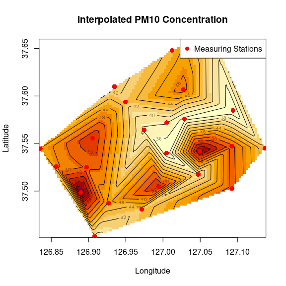

```r
data <- load_data()
intpol(data, "PM10")
```

### 3.3 Daily to Annual Pollution Conversion

The `d2a_conv` function is designed to transform a CSV dataset containing timestamped pollutant measurements into an annual aggregated format. After reading the file, the function converts the specified date column into a Date object and extracts the year information. It then calculates the mean pollutant levels for each year and creates a new aggregated dataset. The returned dataset presents annual averages for the selected pollutants, allowing users to gain insights into long-term trends and changes in pollution levels over time.

```r
data <- load_data()
pollutants <- c("SO2", "NO2", "O3", "CO", "PM10", "PM2.5")
d2a_conv(data = data, date = "Date", pollutants = pollutants)
```

```
#>   Year          SO2        NO2         O3        CO     PM10    PM2.5
#> 1 2019 -0.008785487 0.01506562 0.01129159 0.5168966 46.20541 28.31888
```

### 3.4 Cluster Analysis of Pollutant Profiles

The `clust` function facilitates clustering analysis on a given CSV dataset containing pollutant measurements. Users can choose between the “kmeans” clustering method or receive an error message for unsupported methods. The function reads the file, extracts the specified pollutants’ data, and applies k-means clustering if selected. It displays the clustering results and, if there are multiple clusters, generates a cluster plot with distinctive colors for each cluster. Users can customize the number of clusters using the ‘k’ parameter. The function aids in understanding pollutant profiles’ similarity patterns, allowing for informed decision-making based on cluster memberships.

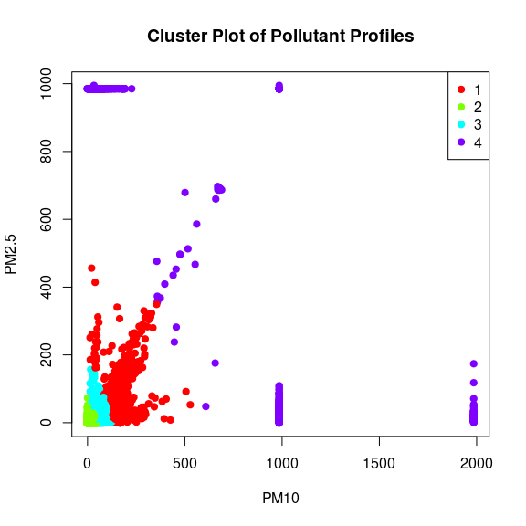

```r
data <- load_data()
pollutants <- c("PM10", "PM2.5")
clust(data, pollutants, method = "kmeans", k = 4)
```

### 3.5 Daily, Monthly Time Series Plot

The `dm_plots` function is designed to visualize time series data from a CSV file, particularly focused on pollutant measurements. After reading the file, the function converts the specified date column into a Date object. It then aggregates the data into daily, monthly, and annual time series formats. For each of the specified pollutants, the function generates plots: first, it displays the daily time series with a line plot, and then it creates a monthly time series plot using a combination of lines and points for better visibility. These plots help users observe trends and variations in pollutant concentrations on both a daily and monthly basis, facilitating the analysis of temporal patterns and potential seasonality in the data.

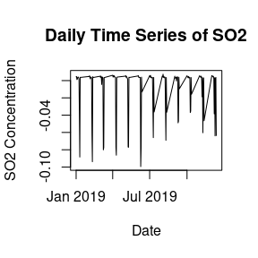

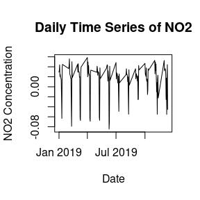

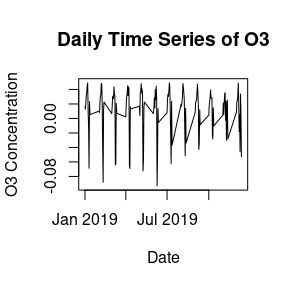

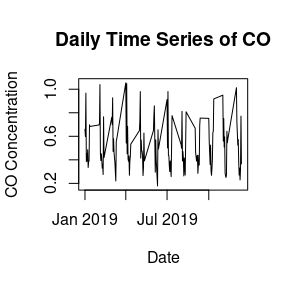

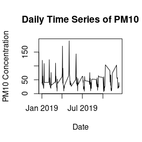

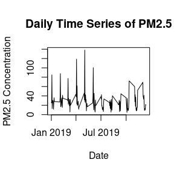

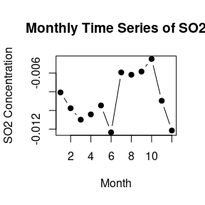

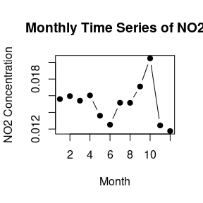

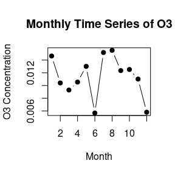

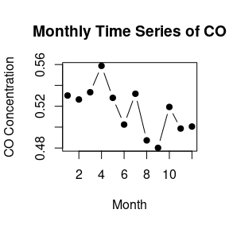

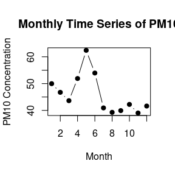

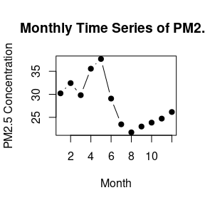

```r
data <- load_data()
dm_plots(data, "Date", pollutants = c("SO2", "NO2", "O3", "CO", "PM10", "PM2.5"))
```

### 3.6 Anomaly Detection

The `anomaldet` function is designed for detecting and visualizing anomalies in time series data related to pollutants. It takes a CSV file with timestamped measurements, identifies anomalies by applying ARIMA modeling and comparing residuals to a threshold, and then generates a plot that showcases the original time series, forecasted values, and detected anomalies. The function’s parameters allow customization of forecasting horizon, ARIMA order, and anomaly threshold. By offering a comprehensive view of anomalies in the context of the time series, the function aids in understanding and addressing irregularities in pollutant data patterns.

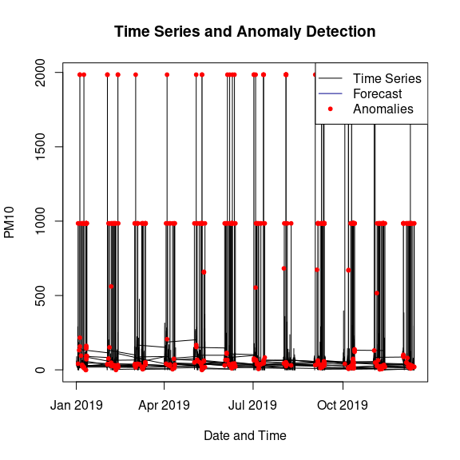

```r
data <- load_data()
anomaldet(data, date_col = "Date", pollutant = "PM10",forecast_horizon = 24,
                             arima_order = c(1, 1, 1), threshold = 2.5)
```

### 3.7 Matrix Plot

[figure not shown]

```r
data <- load_data()
pollutants <- c("SO2", "NO2", "O3", "CO", "PM10", "PM2.5")
matriplot(data, pollutants)
```

### 3.8 Seasonal Analysis

The `seaso` is designed to analyze and visualize the seasonal variations of pollutant levels within a CSV dataset. It performs Longitudinal analysis. After reading the file, it converts the “Date” column into a Date object and extracts year and month information. The function then defines seasons based on the months, categorizing them into Spring, Summer, Fall, and Winter. It initializes an empty data frame to store results and processes each specified pollutant. For each pollutant, the function calculates the average levels for each year and season and stores them in a separate data frame. It merges these results with the main data frame and subsequently generates bar plots for each pollutant, illustrating the average levels over the years and seasons. This allows users to gain insights into the seasonal patterns of pollutant concentrations, aiding in understanding the temporal trends and variations in air quality. The function returns a data frame containing the calculated average levels for further analysis.

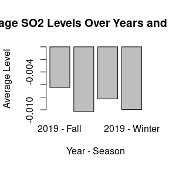

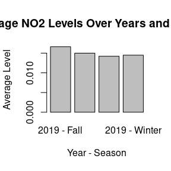

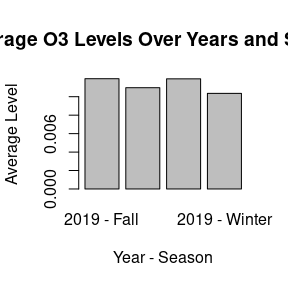

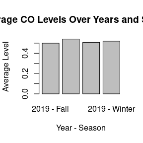

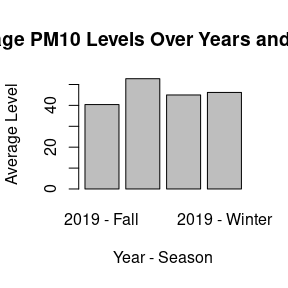

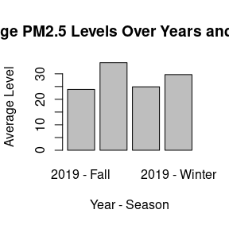

```
#>   Year Season      SO2_Avg    NO2_Avg     O3_Avg    CO_Avg PM10_Avg PM2.5_Avg
#> 1 2019   Fall -0.006458125 0.01662547 0.01194928 0.4994376 40.38491  23.87310
#> 2 2019 Spring -0.010285219 0.01499511 0.01097367 0.5399004 52.76835  34.39568
#> 3 2019 Summer -0.008277488 0.01421985 0.01193813 0.5071872 45.00502  24.89862
#> 4 2019 Winter -0.009957146 0.01449233 0.01035869 0.5194970 46.20015  29.68832
```

```r
data <- load_data()
pollutants <- c("SO2", "NO2", "O3", "CO", "PM10", "PM2.5")
seaso(data, pollutants)
```

### 3.9 Correlation and Regression Analysis

The `correg` function computes the correlation and regression analysis between pairs of specified pollutants in a given CSV dataset. It reads the file, iterates through the provided pollutants, and for each pair, calculates the Pearson correlation coefficient to assess their linear relationship. It further computes the slope and intercept of the regression line to model one pollutant’s potential prediction based on the other. The function then prints the correlation, regression equation, and displays scatter plots with regression lines for each pair of pollutants. This functionality helps users comprehend the statistical association and predictive relationship between chosen pollutants, fostering insights into potential dependencies within environmental or experimental data.

```r
data <- load_data()
pollutants <- c("SO2", "NO2", "O3", "CO", "PM10", "PM2.5")
correg(data, pollutants)
```

```
#> Correlation between SO2 and NO2 : 0.9876792
#> Regression equation: y = 1.021181 * x + 0.02380647
```

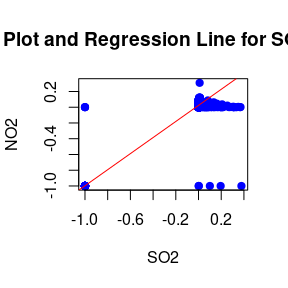

```
#> Correlation between SO2 and O3 : 0.9687778
#> Regression equation: y = 1.018032 * x + 0.02038867
```

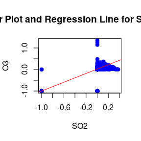

```
#> Correlation between SO2 and CO : 0.3859718
#> Regression equation: y = 1.638128 * x + 0.5281287
```

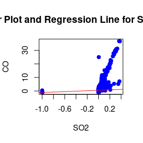

```
#> Correlation between SO2 and PM10 : 0.06245947
#> Regression equation: y = 45.362 * x + 45.38844
```

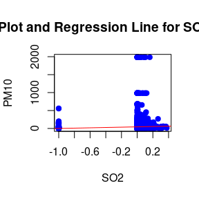

```
#> Correlation between SO2 and PM2.5 : 0.05178964
#> Regression equation: y = 28.3782 * x + 27.85447
```

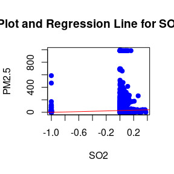

```
#> Correlation between NO2 and O3 : 0.9471051
#> Regression equation: y = 0.9626062 * x + -0.002799159
```

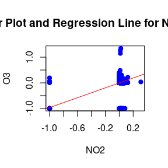

```
#> Correlation between NO2 and CO : 0.4000066
#> Regression equation: y = 1.641999 * x + 0.4893381
```

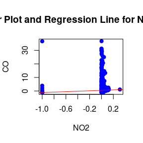

```
#> Correlation between NO2 and PM10 : 0.08362525
#> Regression equation: y = 58.74145 * x + 44.10336
```

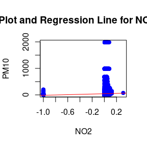

```
#> Correlation between NO2 and PM2.5 : 0.07042286
#> Regression equation: y = 37.32234 * x + 27.04141
```

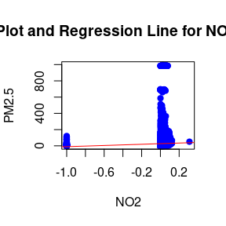

```
#> Correlation between O3 and CO : 0.3231008
#> Regression equation: y = 1.304948 * x + 0.4991225
```

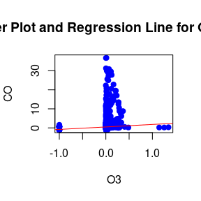

```
#> Correlation between O3 and PM10 : 0.05893944
#> Regression equation: y = 40.73453 * x + 44.52774
```

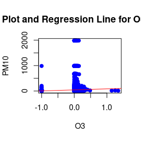

```
#> Correlation between O3 and PM2.5 : 0.04902037
#> Regression equation: y = 25.5612 * x + 27.31505
```

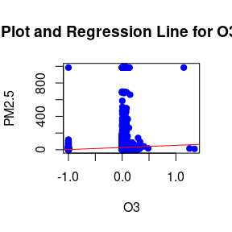

```
#> Correlation between CO and PM10 : 0.1556066
#> Regression equation: y = 26.62746 * x + 31.31221
```

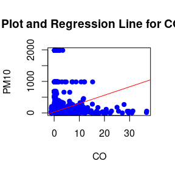

```
#> Correlation between CO and PM2.5 : 0.1492263
#> Regression equation: y = 19.26615 * x + 17.70413
```

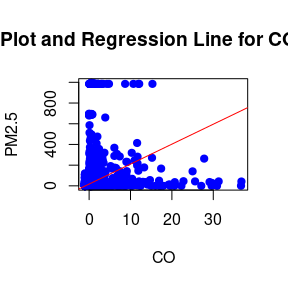

```
#> Correlation between PM10 and PM2.5 : 0.2471675
#> Regression equation: y = 0.1864831 * x + 19.2359
```

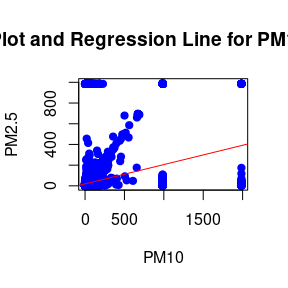

## **4 Conclusion**

The “SAWpollut” R package is a versatile tool for analyzing pollution data across soil, air, and water domains. It offers features like anomaly detection, clustering, correlation analysis, temporal aggregation, and seasonal variation assessment. This package aids researchers, analysts, and policymakers in deriving insights from pollution datasets and making informed decisions. Its user-friendly functions facilitate data integration and exploration, making it a valuable resource for uncovering patterns and trends in pollution measurements. Overall, “SAWpollut” empowers users to contribute to environmental understanding and promote sustainable solutions.